# Librarian Census Data Code

## Kindly check the local languages or dialects you can speak on a conversational level other than Filipino / Tagalog

- Ilocano
- Cebuano
- Ilonggo
- Kapampangan
- Pangasinense
- Waray
- Bicolano
- Others

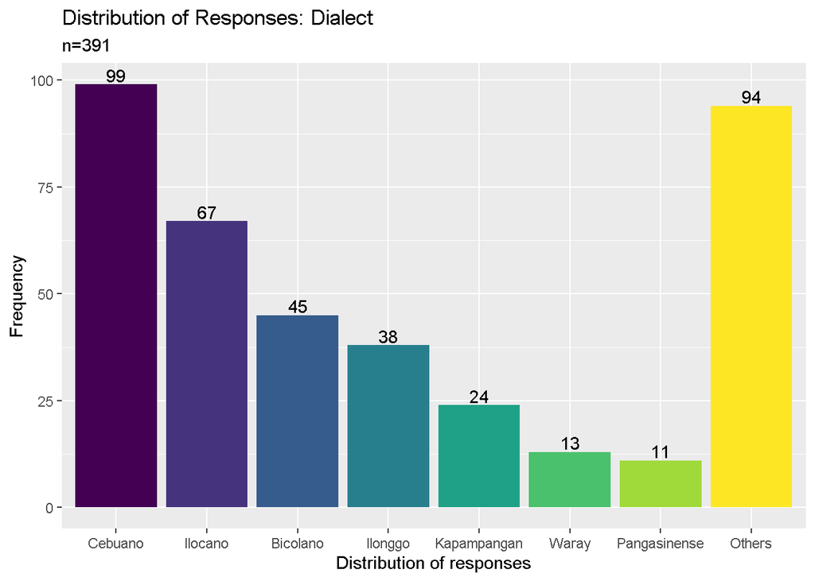

```r
# Change the factor type
dataset$dialect <- as.factor(dataset$dialect)
# Rearrange the responses
dataset$dialect <- factor(dataset$dialect, levels = c('Cebuano', 'Ilocano', 'Bicolano', 'Ilonggo', 'Kapampangan', 'Waray', 'Pangasinense', 'Others'))
# Graph the data
dataset %>%
filter(!is.na(dialect)) %>%
ggplot(aes(x = dialect, fill = dialect)) + geom_bar() + geom_text(aes(label = ..count..), stat = "count", vjust = -0.2, colour = "black") + xlab("Distribution of responses") + ylab("Frequency") + guides(fill = "none") + ggtitle("Distribution of Responses: Dialect", "n=391") + scale_fill_viridis_d()
```

## Kindly indicate any foreign languages or dialects you can speak on a conversational level other than English (if any)

```r
# Create a clean_corpus function
clean_corpus <- function(corpus) {
    corpus <- tm_map(corpus, removePunctuation)
    corpus <- tm_map(corpus, removeNumbers)
    corpus <- tm_map(corpus, content_transformer(tolower))
    corpus <- tm_map(corpus, removeWords, c(stopwords("en"), "none", "can", "kankanaey"))
    corpus <- tm_map(corpus, stripWhitespace)
    return(corpus)
}
# Create a text corpus
topics.corpus <- dataset$foreignlang %>%
VectorSource() %>%
VCorpus()
# Clean the created corpus
topics.corpus <- clean_corpus(topics.corpus)
# Create a wordcount
term.frequency <- topics.corpus %>%
TermDocumentMatrix() %>%
as.matrix() %>%
rowSums() %>%
sort( , decreasing=TRUE)
term.frequency[1:10]
```

```
##  spanish  english  tagalog   french  ilonggo   korean  chinese filipino
##       24       15       11        9        8        8        6        6
##  ilocano   bahasa
##        6        4
```

## Kindly indicate the type of library you are currently working in

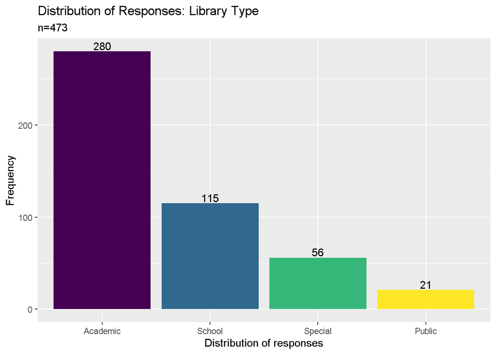

```r
# Change the factor type
dataset$type <- as.factor(dataset$type)
# Recode responses
dataset$type <- fct_recode(dataset$type,
"NA" = '#NAME?',
"NA" = '...',
"Academic" = 'academic',
"Academic" = 'Academic',
"Academic" = 'Academic-Special',
"Academic" = 'Academic - Seminary',
"Academic" = 'Academic (College)',
"Academic" = 'Academic (Government)',
"Academic" = 'Academic (Private-Catholic School)',
"Academic" = 'Academic (University)',
"Academic" = 'academic / private',
"Academic" = 'Academic and Research Library (SUC-University)',
"Academic" = 'academic and school',
"Academic" = 'Academic and school libraries',
"Academic" = 'academic and school library',
"Academic" = 'academic college library',
"Academic" = 'academic library',
"Academic" = 'Academic library',
"Academic" = 'Academic Library',
"Academic" = 'ACADEMIC LIBRARY',
"Academic" = 'Academic Library (Medical/Allied Health)',
"Academic" = 'academic library (university)',
"Academic" = 'Academic library / State university library',
"Academic" = 'Academic library in a Government Institution',
"Academic" = 'Academic library under LGU',
"Academic" = 'Academic Medical Library',
"Academic" = 'Academic State University',
"Academic" = 'academic SUCs',
"Academic" = 'Academic SUCs HEIs',
"Academic" = 'Academic.',
"Academic" = 'Academic/ Research Library',
"Academic" = 'Academic/Government Institutionalize',
"Special" = 'Academic/institutional archives',
"Academic" = 'Academic/Public Library',
"Academic" = 'Academic/Secondary library',
"Academic" = 'Academic/Special Library',
"Academic" = 'Alliance Graduate School Library',
"Academic" = 'An academic library with a 10, 000 student population. The library has 3 sub libraries aside from the main library. The main library also caters to the SHS students. Currently within the main library, the SHS collection is identified separately.',
"Special" = 'Archives',
"Special" = 'Archives or Records Management',
"Special" = 'Archives/Records Management',
"School" =  'Chinese private school',
"Academic" = 'college',
"Academic" = 'college library',
"Academic" = 'College library',
"Academic" = 'College Library',
"Academic" = 'College Library funded by LGU',
"NA" = 'Confidential',
"School" = 'DepEd (School) Library',
"School" = 'DepEd division Library',
"School" = 'Deped library hub',
"School" = 'Division library',
"NA" = 'Freelance',
"Public" = 'Government',
"Special" = 'Government Archives',
"Public" = 'Government library',
"Public" = 'Government Public Library',
"Special" = 'government special library',
"Academic" = 'Government/ Academic',
"Academic" = 'Graduate school',
"School" = 'High school library',
"Academic" = 'I am currently the audio-visual librarian of our university',
"School" = 'IBO K-12',
"School" = 'Junior High School Library',
"Special" = 'Law library',
"Special" = 'Law Library',
"Special" = 'Law Library (Special)',
"Special" = 'Law Library/Special Library',
"Public" = 'LGU library',
"Public" = 'Library Hub',
"School" = 'Library school',
"Academic" = 'LIS school',
"Special" = 'Media Library',
"Academic" =  'Medical and\r\nAllied Health Library',
"Academic" = 'Medical/Academic library',
"Special" = 'Military Library (Special academic library',
"Public" = 'municipal library',
"Public" = 'Municipal Library',
"Special" = 'Museum',
"NA" = 'n/a',
"NA" = 'N/A',
"NA" = 'NA. publishing company',
"NA" = 'NA. Working in a BPO',
"Public" = 'National',
"Special" = 'NGO Digital Library',
"NA" = 'None',
"NA" = 'Not applicable',
"Special" = 'Not in a library but in an archives',
"NA" = 'Not library. GOCC.',
"NA" = 'Not working in a library',
"NA" = 'Not working in a library setting',
"NA" = 'Not working in a library setting since two years ago',
"Special" = 'Not working in a library. Working in a Data Office',
"NA" = 'Private', "Academic" = 'Private academic/school (hybrid) library',
"Academic" =  'private HEI',
"Academic" ='Privately owned libraries (academic)',
"Public" = 'Provincial Library.',
"Public" = 'Public high school library',
"Public" = 'public library',
"Public" = 'Public library',
"Public" = 'Public Library',
"Academic" = 'Public Library/ Academic',
"School" = 'Public school library',
"School" = 'Public School Library',
"School" = 'Public School LIbrary',
"School" = 'Public School Library (Deped Division Office)',
"Special" = 'records center',
"School" = 'school',
"School" = 'School',
"School" = 'School (primary and secondary)',
"Academic" = 'School and Academic library',
"Academic" = 'School and Academic Library',
"School" = 'school library',
"School" = 'School library',
"School" = 'School Library',
"School" = 'School library ( Private)',
"School" = 'School Library (Elementary)',
"School" = 'School Library (Senior High School Library)',
"School" = 'School library (under both DepED and TESDA)',
"Academic" = 'School Library and academic Library',
"School" = 'School library and prefer to be with the academic library soon',
"School" = 'School library and reading center',
"School" = 'School Library specifically Library Hub, a project of the Department of Education',
"School" = 'School library, catering exclusively junior high school students and staff',
"School" = 'School library.',
"Academic" = 'School/Academic Library',
"Academic" = 'School/academic library - Technical Section',
"School" = 'School/Public',
"School" = 'Secondary school library',
"Academic" = 'Slis',
"NA" = 'Spanish, bahasa',
"Special" = 'special',
"Special" = 'Special',
"Special" = 'Special-Public',
"Special" = 'Special (government law) library',
"Special" = 'special academic library',
"Special" = 'special library',
"Special" = 'Special library',
"Special" = 'Special Library',
"Special" = 'SPECIAL LIBRARY',
"Special" = 'Special Library in an Auditing Firm',
"Special" = 'Special library/Archives\r\nDigital records',
"Special" = 'Special library/Government',
"Special" = 'Special Public Library',
"Special" = 'Special/public/research library',
"Special" = 'Special/Research Library',
"Special" = 'specual libray',
"Academic" = 'State u',
"Academic" = 'State University',
"Academic" = 'State university library',
"Academic" = 'State/ Academic',
"Academic" = 'SUC',
"Academic" = 'SUC (Academic Library)',
"Academic" = 'SUC library',
"Academic" = 'SUC Library',
"Special" = 'University Archives',
"Academic" = 'University library',
"Academic" = 'University Library',
"Academic" = 'University Library - at the regional campus specializing in Law')
# Rearrange the responses
dataset$type <- factor(dataset$type, levels = c("Academic", "School", "Special", "Public"))
# Graph the data
dataset %>%
filter(!is.na(type)) %>%
ggplot(aes(x = type, fill = type)) + geom_bar() + geom_text(aes(label = ..count..), stat = "count", vjust = -0.2, colour = "black") + xlab("Distribution of responses") + ylab("Frequency") + guides(fill = "none") + ggtitle("Distribution of Responses: Library Type", "n=473") + scale_fill_viridis_d()
```

## Other than being a librarian, what other roles do you serve in your institution/ organization?

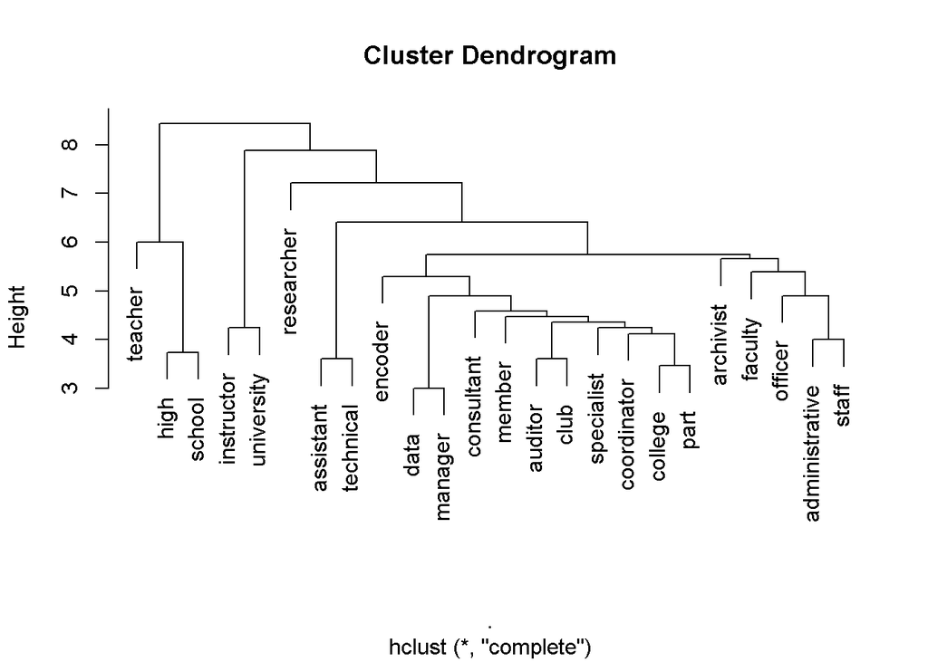

```r
# Create a clean_corpus function
clean_corpus <- function(corpus) {
    corpus <- tm_map(corpus, removePunctuation)
    corpus <- tm_map(corpus, removeNumbers)
    corpus <- tm_map(corpus, content_transformer(tolower))
    corpus <- tm_map(corpus, removeWords, c(stopwords("en"), "library", "librarianship", "none", "librarian"))
    corpus <- tm_map(corpus, stripWhitespace)
    return(corpus)
}
# Create a text corpus
roles.corpus <- dataset$roles %>%
VectorSource() %>%
VCorpus()
# Clean the created corpus
roles.corpus <- clean_corpus(roles.corpus)
# Create a dendogram
roles.corpus %>%
TermDocumentMatrix() %>%
removeSparseTerms(sparse = 0.99) %>%
as.matrix() %>%
dist() %>%
hclust() %>%
plot()
```

## Kindly indicate your current work position

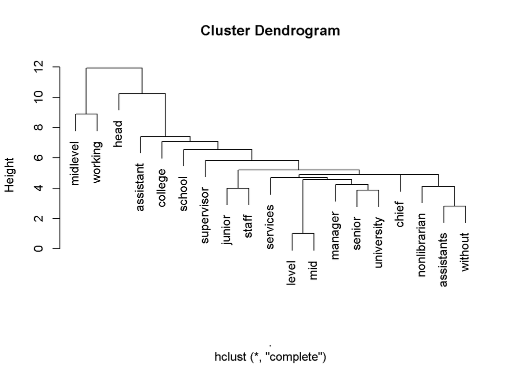

```r
# Create a clean_corpus function
clean_corpus <- function(corpus) {
    corpus <- tm_map(corpus, removePunctuation)
    corpus <- tm_map(corpus, removeNumbers)
    corpus <- tm_map(corpus, content_transformer(tolower))
    corpus <- tm_map(corpus, removeWords, c(stopwords("en"),"iii", "library", "librarianship", "none", "librarian", "sole", "librarians"))
    corpus <- tm_map(corpus, stripWhitespace)
    return(corpus)
}
# Create a text corpus
institutionposition.corpus <- dataset$institutionposition %>%
VectorSource() %>%
VCorpus()
# Clean the created corpus
institutionposition.corpus <- clean_corpus(institutionposition.corpus)
# Create a dendogram
institutionposition.corpus %>%
TermDocumentMatrix() %>%
removeSparseTerms(sparse = 0.99) %>%
as.matrix() %>%
dist() %>%
hclust() %>%
plot()
```

## Kindly indicate your primary job / designation inside the library

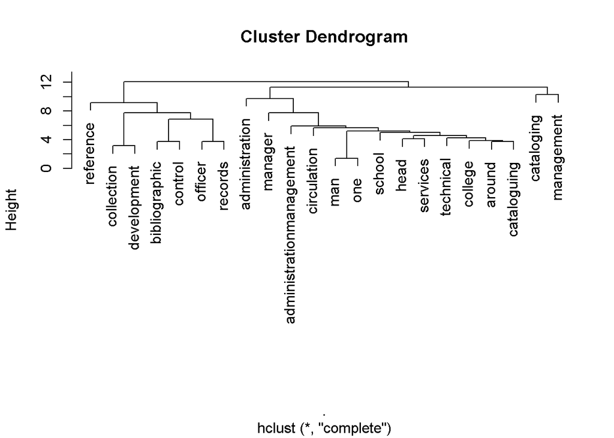

```r
# Create a clean_corpus function
clean_corpus <- function(corpus) {
    corpus <- tm_map(corpus, removePunctuation)
    corpus <- tm_map(corpus, removeNumbers)
    corpus <- tm_map(corpus, content_transformer(tolower))
    corpus <- tm_map(corpus, removeWords, c(stopwords("en"),"iii", "library", "librarianship", "none", "librarian", "sole", "librarians"))
    corpus <- tm_map(corpus, stripWhitespace)
    return(corpus)
}
# Create a text corpus
primaryjob.corpus <- dataset$primaryjob %>%
VectorSource() %>%
VCorpus()
# Clean the created corpus
primaryjob.corpus <- clean_corpus(primaryjob.corpus)
# Create a dendogram
primaryjob.corpus %>%
TermDocumentMatrix() %>%
removeSparseTerms(sparse = 0.99) %>%
as.matrix() %>%
dist() %>%
hclust() %>%
plot()
```

## Kindly indicate your current / existing professional affiliations

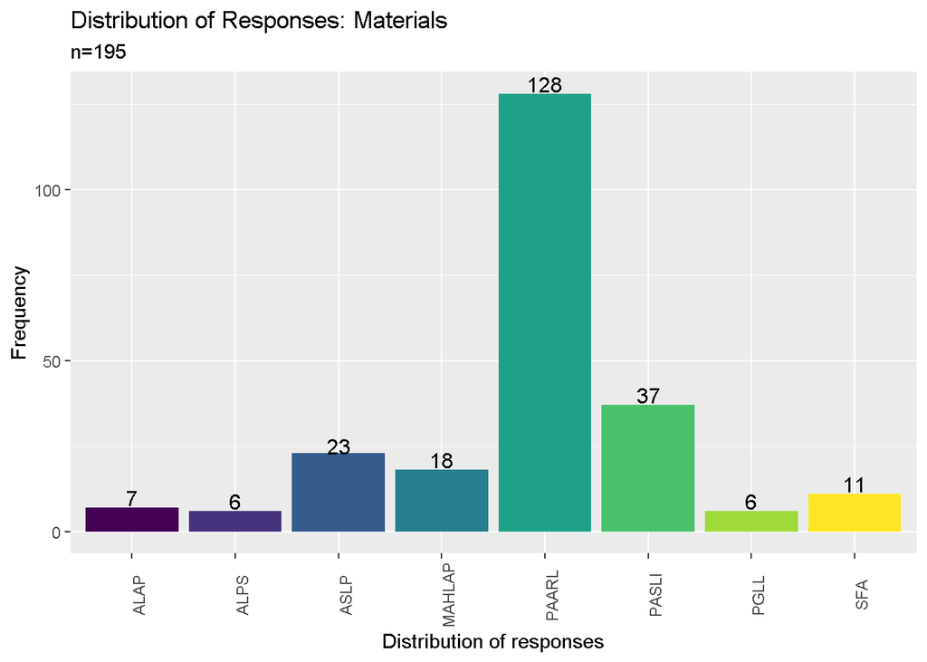

```r
# Change the factor type
dataset$affiliation <- as.factor(dataset$affiliation)
# Recode factors
levels(dataset$affiliation)[143] <- "PLAI, PAARL, RIzalenos Librarians Association, USTLISAA"
levels(dataset$affiliation)[144] <- "PLAI, PAARL, RLA Rizalenos Librarians Association"
dataset$affiliation <- fct_recode(dataset$affiliation,
"ALPS" = 'ALPS',
"ASLP" = 'ASLP' ,
"PASLI" = 'before member of PASLI and PLAI-CeLRLC' ,
"NA" = 'Bplai' ,
"NA" = 'CLAI' ,
"NA" = 'DepEd' ,
"NA" = 'Dont renew yet my membership in PLAI' ,
"NA" = 'Haven\'t join any organization' ,
"NA" = 'I have not yet member seen i have a license' ,
"NA" = 'Inactive member of PLAI' ,
"LAQUEP" = 'Laquep, Plai stlrc' ,
"MAHLAP" = 'MAHLAP' ,
"MAHLAP PATLS" = 'MAHLAP /PATLS /PLAI' ,
"MAHLAP PAARL" = 'MAHLAP, PLAI, PAARL, ABCLI, PUPLSAAI, PAMJE, MLA' ,
"NA" = 'n/a' ,
"NA" = 'N/A' ,
"NA" = 'Na' ,
"NA" = 'NELAI (Nueva Ecija Librarian\'s Association, Inc.)' ,
"PAARL" = 'NELAI,  PLAI,  PAARL' ,
"NA" = 'none' ,
"NA" = 'None' ,
"NA" = 'NONE' ,
"NA" = 'None this year.' ,
"NA" = 'None yet' ,
"PAARL" = 'Paarl' ,
"PAARL" = 'PAARL' ,
"PAARL PASLI" = 'PAARL, PASLI' ,
"PAARL" = 'paarl, plai' ,
"PAARL" = 'PAARL, PLAI' ,
"PAARL PATLS" = 'PAARL, PLAI, PATLS, CODHLIS' ,
"PASLI" = 'PADLI' ,
"PASLI" = 'Pasli' ,
"PASLI" = 'PASLI' ,
"PASLI" = 'PASLI, PLAI' ,
"PASLI" = 'PASLI, PLAI, MUNPARLAS' ,
"PASLI" = 'PASLI, PNULISAA' ,
"PATLS" = 'PATLS' ,
"NA" = 'PLA' ,
"NA" = 'plai' ,
"NA" = 'Plai' ,
"NA" = 'PLAI' ,
"NA" = 'PLAI-CARAGA' ,
"NA" = 'PLAI-Caraga, CLLA, MINLA, MISORLA' ,
"NA" = 'PLAI-Davao' ,
"NA" = 'PLAI-IRLC' ,
"PAARL PATLS" = 'PLAI \r\nPAARL\r\nPATLS' ,
"MAHLAP" = 'PLAI & MAHLAP\r\nbut not renewed membership with PLAI and MAHLAP for the past 2 years.' ,
"PASLI" = 'PLAI & PASLI' ,
"NA" = 'PLAI (PLAI-BRLC)' ,
"NA" = 'PLAI , CoLiNet' ,
"PGLL ASLP SFA" = 'PLAI / PGLL / ASLP / SFA' ,
"NA" = 'PLAI and Bicol Region Librarians Council' ,
"NA" = 'PLAI and CLAI' ,
"MAHLAP" = 'PLAI and MAHLAP' ,
"MAHLAP" = 'PLAI AND MAHLAP' ,
"NA" = 'PLAI and MASTLINET' ,
"PAARL" = 'PLAI and Paarl' ,
"PAARL" = 'PLAI and PAARL' ,
"PASLI" = 'PLAI and PASLI' ,
"SFA" = 'PLAI and SFA' ,
"ASLP" = 'plai aslp' ,
"PAARL" = 'PLAI PAARL CAMANAVA' ,
"PAARL" = 'PLAI PAARL PNULISAA  Asso of Laguna Librarians' ,
"PGLL SFA" = 'PLAI PGLL SFA' ,
"NA" = 'PLAI STRLC, ALLPI\r\nPAARL (but have not yet renewed)' ,
"NA" = 'PLAI WVRLC' ,
"ASLP PAARL" = 'PLAI\r\nASLP\r\nPAARL' ,
"PATLS" = 'Plai\r\nCodhlis\r\nPatls' ,
"NA" = 'PLAI\r\nFORATL' ,
"MAHLAP" = 'PLAI\r\nMAHLAP' ,
"PAARL" = 'plai\r\npaarl' ,
"PAARL" = 'Plai\r\nPaarl' ,
"PAARL" = 'PLAI\r\nPAARL' ,
"PAARL" = 'PLAI\r\nPAARL\r\nAASDI' ,
"PAARL ASLP" = 'PLAI\r\nPAARL\r\nASLP' ,
"PAARL" = 'PLAI\r\nPAARL\r\nLAQueP-LInc' ,
"PAARL PATLS" = 'PLAI\r\nPAARL\r\nPATLS' ,
"PAARL" = 'Plai\r\nPaarl\r\nQCLC' ,
"PAARL SFA" = 'plai\r\nPaarl\r\nSfa\r\nAasdi\r\nKbp' ,
"PASLI" = 'PLAI\r\nPASLI' ,
"PASLI" = 'PLAI\r\nPASLI\r\nLLAI\r\nPLAI -ARMM' ,
"NA" = 'PLAI\r\nPNULISAA' ,
"NA" = 'PLAI\r\nPUP LSAA' ,
"NA" = 'PLAI\r\nSOCOLA' ,
"NA" = 'PLAI,' ,
"NA" = 'PLAI,  NIRLC' ,
"PAARL" = 'PLAI,  PAARL' ,
"NA" = 'PLAI, AASDI' ,
"ALAP" = 'PLAI, ALAP' ,
"ASFA" = 'PLAI, ALINET, ASFA, IAMSLIC' ,
"NA" = 'PLAI, ALINET, MASTLINET, LLAI' ,
"NA" = 'PLAI, ALINET, PLAI CRLC' ,
"ALPS" = 'PLAI, ALPS' ,
"ALPS" = 'PLAI, ALPS, LAQueP-LInc' ,
"PASLI" = 'PLAI, and PASLI' ,
"ALPS" = 'PLAI, APLIN, ALPS' ,
"NA" = 'PLAI, APPLI, NEFLI' ,
"ASLP" = 'PLAI, ASLP' ,
"ASLP SFA" = 'PLAI, ASLP, ICA, SFA' ,
"ASLP SLA" = 'PLAI, ASLP, SLA' ,
"ASLP" = 'PLAI, ASLP, UELISAAI' ,
"NA" = 'PLAI, ASSDI' ,
"NA" = 'PLAI, BPLAI' ,
"NA" = 'PLAI, BRLC' ,
"NA" = 'PLAI, Cagayan Valley Regional Librarians Association, Inc.; Nueva Vizcaya Librarians Association' ,
"NA" = 'PLAI, Cavite Librarians Inc.,' ,
"NA" = 'PLAI, CLAI' ,
"MAHLAP" = 'Plai, clai, mahlap' ,
"PAARL" = 'PLAI, CLAI, PAARL' ,
"NA" = 'PLAI, CLLA, Inc.' ,
"NA" = 'PLAI, DACUN' ,
"NA" = 'PLAI, DACUN, MASTLINET' ,
"NA" = 'PLAI, ICA, UPLSAA' ,
"NA" = 'PLAI, LAQUEPLINC,' ,
"MAHLAP" = 'Plai, mahlap' ,
"MAHLAP" = 'PLAI, MAHLAP' ,
"NA" = 'PLAI, MUNPARLAS' ,
"ASLP" = 'PLAI, MUNPARLAS, ASLP' ,
"NA" = 'PLAI, OMLA' ,
"PAARL" = 'plai, paarl' ,
"PAARL" = 'Plai, paarl' ,
"PAARL" = 'PLAi, PAARL' ,
"PAARL" = 'PLAI, pAARL' ,
"PAARL" = 'PLAI, PAARL' ,
"PAARL" = 'PLAI, PAARL and QCLC' ,
"PAARL" = 'PLAI, PAARL,' ,
"PAARL" = 'PLAI, PAARL, AASDI' ,
"PAARL" = 'PLAI, PAARL, ABCLI, QCLC' ,
"PAARL" = 'PLAI, PAARL, ALA' ,
"PAARL ALAP" = 'PLAI, PAARL, ALAP' ,
"PAARL ALAP" = 'PLAI, PAARL, ALAP, AASDI' ,
"PAARL ALAP" = 'PLAI, PAARL, ALAP, ALLPI' ,
"PAARL ASLP" = 'PLAI, PAARL, ASLP' ,
"PAARL ASLP MAHLAP SLA" = 'PLAI, PAARL, ASLP, MAHLAP, SLA' ,
"PAARL" = 'PLAI, PAARL, BLAI' ,
"PAARL MAHLAP" = 'PLAI, PAARL, MAHLAP' ,
"PAARL MAHLAP" = 'PLAI, PAARL, MAHLAP (Local), MLA (international)' ,
"PAARL PGLL" = 'PLAI, PAARL, PGLL, PUPLSAA' ,
"PAARL" = 'PLAI, PAARL, PLAI-STRLC' ,
"PAARL" = 'PLAI, PAARL, PNULISAA' ,
"PAARL" = 'PLAI, PAARL, PUPLSAA' ,
"PAARL" = 'PLAI, PAARL, QCLC (Quezon City Library Consortium)' ,
"PAARL" = 'PLAI, PAARL, RIzalenos Librarians Association, USTLISAA' ,
"PAARL" = 'PLAI, PAARL, RLA Rizalenos Librarians Association' ,
"PAARL" = 'PLAI, PAARL, UPLSAA' ,
"PAARL" = 'PLAI, PAARL, UPLSAA, PUPLSAA' ,
"PAARL" = 'PLAI, PAARL, Vanuatu Librarians\' Association' ,
"PAARL" = 'PLAI, PAARL, Western Visayas Association of Museums' ,
"PAARL PASLI" = 'PLAI, PAARL,PASLI' ,
"PAARL PASLI" = 'PLAI, PADLI' ,
"PAARL PASLI" = 'PLAI, PASLI' ,
"PAARL PASLI" = 'PLAI, PASLI, LAQueP-LInc, MUNPARLAS' ,
"PAARL PASLI" = 'PLAI, PASLI, UPLSAA' ,
"PAARL PATLS" = 'PLAI, PATLS' ,
"PAARL PATLS SFA" = 'Plai, patls, sfa' ,
"PAARL PATLS SFA" = 'PLAI, PATLS, SFA' ,
"NA" = 'Plai, pearl, clla' ,
"PGLL" = 'PLAI, PGLL' ,
"PGLL" = 'PLAI, PGLL, and LLIWA' ,
"PGLL SFA" = 'PLAI, PGLL, SFA' ,
"NA" = 'Plai, Plai-Central luzon, Nueva ecija librarian association' ,
"NA" = 'PLAI, PLAI-NIRLC' ,
"NA" = 'PLAI, PLAI-RLC' ,
"ALPS" = 'PLAI, PLAI-STRLC, ALPS, LAQueP-LInc' ,
"NA" = 'PLAI, PLAI-STRLC, OMLA' ,
"NA" = 'PLAI, PLAI - IRLC' ,
"NA" = 'PLAI, PSPL, BOLA' ,
"NA" = 'plai, regional council for librarians' ,
"SFA" = 'PLAI, SFA' ,
"NA" = 'PLAI, UPLSAA' ,
"ASLP" = 'PLAI,ASLP' ,
"PASLI" = 'PLAI,PASLI' ,
"PATLS" = 'PLAI,PATLS, CODHLIS' ,
"NA" = 'PLAI.' ,
"PAARL" = 'PLAI; PAARL' ,
"PAARL" = 'PLAI< PAARL' ,
"PASLI" = 'Plain and Philippine Association of DepEd Librarians,Inc. (PADLI)' ,
"NA" = 'PLAL' ,
"NA" = 'PNULISAA' ,
"NA" = 'QCLC' ,
"NA" = 'RLA' ,
"NA" = 'UPLSAA')
# Create new columns: PAARL, PASLI, ASLP, MAHLAP, PATLS, ALAP, ALPS, PGLL, SFA
dataset <- transform(dataset,
                     PAARL = grepl("PAARL",affiliation),
                     PASLI = grepl("PASLI", affiliation),
                     ASLP = grepl("ASLP", affiliation),
                     MAHLAP = grepl("MAHLAP", affiliation),
                     PATLS = grepl("PATLS", affiliation),
                     ALAP = grepl("ALAP", affiliation),
                     ALPS = grepl("ALPS", affiliation),
                     PGLL = grepl("PGLL", affiliation),
                     SFA = grepl("SFA", affiliation))
# Summarize by counting the TRUE values per materials
dataset %>%
summarise("PAARL" = sum(PAARL == TRUE),
          "PASLI" = sum(PASLI == TRUE),
          "ASLP" = sum(ASLP == TRUE),
          "MAHLAP" = sum(MAHLAP == TRUE),
          "ALAP" = sum(ALAP == TRUE),
          "ALPS" = sum(ALPS == TRUE),
          "PGLL" = sum(PGLL == TRUE),
          "SFA" = sum(SFA == TRUE)) %>%
gather() %>%
ggplot(aes(x = key, y= value, fill = key)) + geom_col(position = "dodge") + xlab("Distribution of responses") + ylab("Frequency") + ggtitle("Distribution of Responses: Materials", "n=195") + guides(fill = "none") + scale_fill_viridis_d() + theme(axis.text.x = element_text(angle = 90)) +
geom_text(x = 1, y = 10, label = "7", colour = "black", size = 4) +
geom_text(x = 2, y = 9, label = "6", colour = "black", size = 4) +
geom_text(x = 3, y = 25, label = "23", colour = "black", size = 4) +
geom_text(x = 4, y = 21, label = "18", colour = "black", size = 4) +
geom_text(x = 5, y = 131, label = "128", colour = "black", size = 4) +
geom_text(x = 6, y = 40, label = "37", colour = "black", size = 4) +
geom_text(x = 7, y = 9, label = "6", colour = "black", size = 4) +
geom_text(x = 8, y = 14, label = "11", colour = "black", size = 4)
```

## Kindly indicate what factors influence your decision when it comes to joining a professional organization?

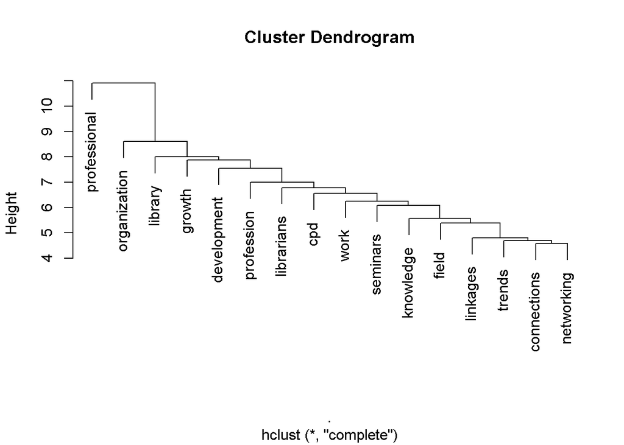

```r
# Create a clean_corpus function
clean_corpus <- function(corpus) {
    corpus <- tm_map(corpus, removePunctuation)
    corpus <- tm_map(corpus, removeNumbers)
    corpus <- tm_map(corpus, content_transformer(tolower))
    corpus <- tm_map(corpus, removeWords, c(stopwords("en")))
    corpus <- tm_map(corpus, stripWhitespace)
    return(corpus)
}
# Create a text corpus
factor.corpus <- dataset$factor %>%
VectorSource() %>%
VCorpus()
# Clean the created corpus
factor.corpus <- clean_corpus(factor.corpus)
# Create a dendogram
factor.corpus %>%
TermDocumentMatrix() %>%
removeSparseTerms(sparse = 0.985) %>%
as.matrix() %>%
dist() %>%
hclust() %>%
plot()
```

```r
glimpse(dataset)
```

```
## Rows: 684
## Columns: 107
```

```
## $ voter                <dbl> 1, 2, 3, 4, 5, 6, 7, 8, 9, 10, 11, 12, 13, 14, 15…
## $ licensed             <fct> Licensed librarian, Licensed librarian, Licensed …
## $ philippines          <fct> NA, Residing outside of the Philippines, Residing…
## $ gender               <fct> NA, Prefer not to say, Female, Male, Male, Male, …
## $ age                  <dbl> 59, 100, 40, 46, 32, 46, 48, 44, 25, 24, 34, 39, …
## $ working              <fct> NA, Retired, Employed, Employed, Employed, Employ…
## $ industry             <fct> NA, ICT, Academe, Academe, Academe, Academe, Acad…
## $ years_service        <dbl> NA, 60, 14, 23, 10, 24, 23, 12, 5, 1, 12, 18, 14,…
## $ institution          <fct> NA, Private, Government, Government, Government, …
## $ tenure               <fct> NA, Self-employed, Permanent, Permanent, Contract…
## $ gross_salary         <dbl> NA, 100, 51, 53, 40, 56, 36, 38, 19, 11, 95, 58, …
## $ net_salary           <dbl> NA, 100, 30, 38, 30, 42, 29, 26, NA, 10, 95, 36, …
## $ benefits1            <fct> NA, night differential pay, paid vacation and/or …
## $ benefits2            <chr> NA, NA, "monetary allowances", "monetary allowanc…
## $ benefits3            <chr> NA, NA, NA, NA, NA, NA, NA, NA, NA, NA, NA, NA, "…
```

[output cut: 92 more lines]

```r
# Save the updated dataset
write_rds(dataset, "LibrarianCensus.rds")
```